# COVID ANALYSIS

Nikhil Gupta

9/17/2021

# **INTRODUCTION** :

The purpose of this project is to analyse the data related to covid-19 cases as well as deaths, collected at the country level (United States) and The global level and produce a reproducible report in R.

### The questions of interest are :

- Analyzing and Plotting the covid -19 cases and deaths till date for the entire US nation.
- Analyzing and Plotting the covid -19 cases and deaths till date for a particular state of interest (New York)
- Analysing and Plotting the daily new cases/deaths curve for the entire US nation
- Analysing and Plotting the daily new cases/deaths curve for a particular state of interest (New York)
- List of top 10 worst performing US states having highest death rates ( deaths per thousand population)
- List of top 10 best performing US states having lowest death rates ( deaths per thousand population)
- Creating a linear Model to predict probable death rates(deaths/thousand people) for perspective case rates(cases/thousand people)

### Data Source :

The source of our data is **[Johns Hopkins University]https://github.com/CSSEGISandData/COVID-19 github sites.**

This is the data repository for the 2019 Novel Coronavirus Visual Dashboard operated by the Johns Hopkins University Center for Systems Science and Engineering **(JHU CSSE)**. Also, Supported by ESRI Living Atlas Team and the Johns Hopkins University Applied Physics Lab (JHU APL).

The data contains **multiple .csv files** containing daily covid-19 cases and deaths for various **nations of the world** as well as the detailed (county level) data for **United States of America**.

#### Importing relevant *libraries*

```r
library(tidyverse)
library(lubridate)
```

```r
library(dplyr)
library(ggplot2)
```

#### Importing the data for Analysis

```r
url_in <- "https://raw.githubusercontent.com/CSSEGISandData/COVID-19/master/csse_covid_19_data/csse_covid_19_time_series/time_series_covid19_"
file_names <- c("confirmed_global.csv",
                "deaths_global.csv",
                "confirmed_US.csv",
                "deaths_US.csv")
urls <- str_c(url_in,file_names)

global_cases <- read_csv(urls[1], show_col_types = FALSE)
global_deaths <- read_csv(urls[2], show_col_types = FALSE)
US_cases <- read_csv(urls[3], show_col_types = FALSE)
US_deaths <- read_csv(urls[4], show_col_types = FALSE)

# The above code imports the data into 4 different csv files.
```

#### Tyding the global data :

- Pivoting the dates columns into rows.
- Renaming certain attributes to make the tibble more friendly.*
- Joining the global_cases and global_deaths into **global** using a **full joint**

```r
global_cases <- global_cases %>%
  pivot_longer(cols = -c(`Province/State`,
                         `Country/Region`, Lat, Long),
               names_to = "date",
               values_to = "cases") %>%
  select(-c(Lat,Long))  # removing lat, longs

print(global_cases)
```

```
## # A tibble: 169,911 x 4
##    `Province/State` `Country/Region` date    cases
##    <chr>            <chr>            <chr>   <dbl>
##  1 <NA>             Afghanistan      1/22/20     0
##  2 <NA>             Afghanistan      1/23/20     0
##  3 <NA>             Afghanistan      1/24/20     0
##  4 <NA>             Afghanistan      1/25/20     0
##  5 <NA>             Afghanistan      1/26/20     0
##  6 <NA>             Afghanistan      1/27/20     0
##  7 <NA>             Afghanistan      1/28/20     0
##  8 <NA>             Afghanistan      1/29/20     0
##  9 <NA>             Afghanistan      1/30/20     0
## 10 <NA>             Afghanistan      1/31/20     0
## # ... with 169,901 more rows
```

```r
global_deaths <- global_deaths %>%
  pivot_longer(cols = -c(`Province/State`,
                         `Country/Region`, Lat, Long),
               names_to = "date",
               values_to = "deaths") %>%
  select(-c(Lat, Long))

global <- global_cases %>%
  full_join(global_deaths) %>%
  rename(Country_Region = `Country/Region`,
         Province_State = `Province/State`) %>%
  mutate(date = mdy(date))
print(global)
```

```
## # A tibble: 169,911 x 5
##    Province_State Country_Region date       cases deaths
##    <chr>          <chr>          <date>     <dbl>  <dbl>
##  1 <NA>           Afghanistan    2020-01-22     0      0
##  2 <NA>           Afghanistan    2020-01-23     0      0
##  3 <NA>           Afghanistan    2020-01-24     0      0
##  4 <NA>           Afghanistan    2020-01-25     0      0
##  5 <NA>           Afghanistan    2020-01-26     0      0
##  6 <NA>           Afghanistan    2020-01-27     0      0
##  7 <NA>           Afghanistan    2020-01-28     0      0
##  8 <NA>           Afghanistan    2020-01-29     0      0
##  9 <NA>           Afghanistan    2020-01-30     0      0
## 10 <NA>           Afghanistan    2020-01-31     0      0
## # ... with 169,901 more rows
```

#### **Cleaning** the data set

- looking at the *summary of the data* to see if there are any problems.

```r
summary(global)
```

```
##  Province_State     Country_Region          date                cases
##  Length:169911      Length:169911      Min.   :2020-01-22   Min.   :       0
##  Class :character   Class :character   1st Qu.:2020-06-22   1st Qu.:     146
##  Mode  :character   Mode  :character   Median :2020-11-21   Median :    2318
##                                        Mean   :2020-11-21   Mean   :  288108
##                                        3rd Qu.:2021-04-22   3rd Qu.:   52404
##                                        Max.   :2021-09-21   Max.   :42410607
##      deaths
##  Min.   :     0.0
##  1st Qu.:     1.0
##  Median :    35.0
##  Mean   :  6637.6
##  3rd Qu.:   851.5
##  Max.   :678407.0
```

- Several rows have zero cases. hence, removing the rows with zero cases.

```r
global <- global %>% filter(cases > 0)
```

#### Tyding the US data :

- Pivoting the dates columns into rows.
- Removing extra attibutes like latitudes and longitudes.
- Joining the US_cases and US_deaths into **US** using a **full joint**

```r
#creating dates Vs cases columns.

US_cases <- US_cases %>%
  pivot_longer(cols = -(UID:Combined_Key),
               names_to = "date",
               values_to = "cases") %>%
  select(Admin2:cases) %>%
  mutate(date = mdy(date)) %>%
  select(-c(Lat, Long_))        # removing the latitudes and longitudes.


#creating dates Vs deaths columns

US_deaths <- US_deaths %>%
  pivot_longer(cols = -(UID:Population),
               names_to = "date",
               values_to ="deaths") %>%
  select(Admin2:deaths) %>%
  mutate(date = mdy(date)) %>%
  select(-c(Lat, Long_))

# joining the US deathts and cases dataset
US <- US_cases %>%
  full_join(US_deaths)
print(US)
```

```
## # A tibble: 2,035,278 x 8
##    Admin2  Province_State Country_Region Combined_Key date       cases Population
##    <chr>   <chr>          <chr>          <chr>        <date>     <dbl>      <dbl>
##  1 Autauga Alabama        US             Autauga, Al~ 2020-01-22     0      55869
##  2 Autauga Alabama        US             Autauga, Al~ 2020-01-23     0      55869
##  3 Autauga Alabama        US             Autauga, Al~ 2020-01-24     0      55869
##  4 Autauga Alabama        US             Autauga, Al~ 2020-01-25     0      55869
##  5 Autauga Alabama        US             Autauga, Al~ 2020-01-26     0      55869
##  6 Autauga Alabama        US             Autauga, Al~ 2020-01-27     0      55869
##  7 Autauga Alabama        US             Autauga, Al~ 2020-01-28     0      55869
##  8 Autauga Alabama        US             Autauga, Al~ 2020-01-29     0      55869
##  9 Autauga Alabama        US             Autauga, Al~ 2020-01-30     0      55869
## 10 Autauga Alabama        US             Autauga, Al~ 2020-01-31     0      55869
## # ... with 2,035,268 more rows, and 1 more variable: deaths <dbl>
```

#### Updating the global dataset to include **population data**

The global dataset does not contain any population data. Hence, to do comparitive analysis among different countries, we are adding population data to it. Also we are making a new column *combined key* to represent holistic location identity.

```r
global <- global %>%
  unite("Combined_Key",
        c(Province_State, Country_Region),
        sep = ", ",
        na.rm = TRUE,
        remove = FALSE)

#adding population

uid_lookup_url <- "https://raw.githubusercontent.com/CSSEGISandData/COVID-19/master/csse_covid_19_data/UID_ISO_FIPS_LookUp_Table.csv"
uid <- read_csv(uid_lookup_url) %>%
  select(-c(Lat, Long_, Combined_Key, code3, iso2, iso3, Admin2))
print(uid)
```

```
## # A tibble: 4,196 x 5
##      UID FIPS  Province_State Country_Region      Population
##    <dbl> <chr> <chr>          <chr>                    <dbl>
##  1     4 <NA>  <NA>           Afghanistan           38928341
##  2     8 <NA>  <NA>           Albania                2877800
##  3    12 <NA>  <NA>           Algeria               43851043
##  4    20 <NA>  <NA>           Andorra                  77265
##  5    24 <NA>  <NA>           Angola                32866268
##  6    28 <NA>  <NA>           Antigua and Barbuda      97928
##  7    32 <NA>  <NA>           Argentina             45195777
##  8    51 <NA>  <NA>           Armenia                2963234
##  9    40 <NA>  <NA>           Austria                9006400
## 10    31 <NA>  <NA>           Azerbaijan            10139175
## # ... with 4,186 more rows
```

Adding the population data to the *global* dataset using **left joint.**

```r
global <- global %>%
  left_join(uid, by = c("Province_State", "Country_Region")) %>%
  select(-c(UID, FIPS)) %>%
  select(Province_State, Country_Region, date, #selection in a particular order
         cases, deaths, Population,
         Combined_Key)
print(global)
```

```
## # A tibble: 153,895 x 7
##    Province_State Country_Region date       cases deaths Population Combined_Key
##    <chr>          <chr>          <date>     <dbl>  <dbl>      <dbl> <chr>
##  1 <NA>           Afghanistan    2020-02-24     5      0   38928341 Afghanistan
##  2 <NA>           Afghanistan    2020-02-25     5      0   38928341 Afghanistan
##  3 <NA>           Afghanistan    2020-02-26     5      0   38928341 Afghanistan
##  4 <NA>           Afghanistan    2020-02-27     5      0   38928341 Afghanistan
##  5 <NA>           Afghanistan    2020-02-28     5      0   38928341 Afghanistan
##  6 <NA>           Afghanistan    2020-02-29     5      0   38928341 Afghanistan
##  7 <NA>           Afghanistan    2020-03-01     5      0   38928341 Afghanistan
##  8 <NA>           Afghanistan    2020-03-02     5      0   38928341 Afghanistan
##  9 <NA>           Afghanistan    2020-03-03     5      0   38928341 Afghanistan
## 10 <NA>           Afghanistan    2020-03-04     5      0   38928341 Afghanistan
## # ... with 153,885 more rows
```

#### ** Data Visualization and Analysis**

Considering the US data set and analysing it for each state.

##### Making a **US_by_state** dataset to have state-wise statistics of covid cases and deaths till date.

```r
#Clubbing all the county data(Admin2) to their respective states

US_by_state <- US %>%
  group_by(Province_State, Country_Region, date) %>%
  summarize(cases = sum(cases), deaths = sum(deaths),
            Population = sum(Population)) %>%
  mutate(deaths_per_mill = deaths *1000000 / Population) %>%
  select(Province_State, Country_Region, date,
         cases, deaths, deaths_per_mill, Population) %>%
  ungroup()
```

##### Making a **US_totals** dataset to have a complete picture of US’s covid cases and deaths at the Nation Level till date.

```r
# Clubbing all the US states data to the Federal(US) level.

US_totals <- US_by_state %>%
  group_by(Country_Region, date) %>%
  summarize(cases = sum(cases), deaths = sum(deaths),
            Population = sum(Population)) %>%
  mutate(deaths_per_mill = deaths *1000000 / Population) %>%
  select(Country_Region, date,
         cases, deaths, deaths_per_mill, Population) %>%
  ungroup()
print(US_totals)
```

```
## # A tibble: 609 x 6
##    Country_Region date       cases deaths deaths_per_mill Population
##    <chr>          <date>     <dbl>  <dbl>           <dbl>      <dbl>
##  1 US             2020-01-22     1      1         0.00300  332875137
##  2 US             2020-01-23     1      1         0.00300  332875137
##  3 US             2020-01-24     2      1         0.00300  332875137
##  4 US             2020-01-25     2      1         0.00300  332875137
##  5 US             2020-01-26     5      1         0.00300  332875137
##  6 US             2020-01-27     5      1         0.00300  332875137
##  7 US             2020-01-28     5      1         0.00300  332875137
##  8 US             2020-01-29     6      1         0.00300  332875137
##  9 US             2020-01-30     6      1         0.00300  332875137
## 10 US             2020-01-31     8      1         0.00300  332875137
## # ... with 599 more rows
```

#### Plotting the total US’s cases and deaths till date.

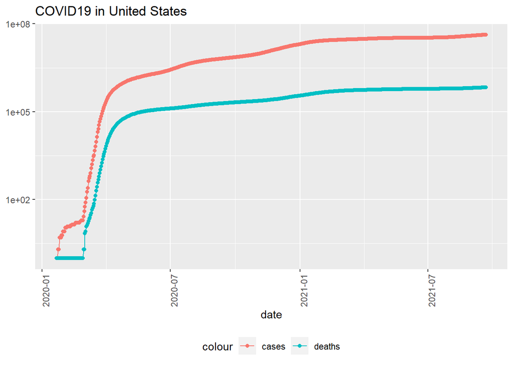

```r
US_totals %>%
  filter(cases > 0) %>%
  ggplot(aes(x = date, y = cases)) +
  geom_line(aes(color = "cases")) +
  geom_point(aes(color = "cases")) +
  geom_line(aes(y = deaths, color = "deaths")) +
  geom_point(aes(y = deaths, color = "deaths")) +
  scale_y_log10() +
  theme(legend.position="bottom",
        axis.text.x = element_text(angle = 90)) +
  labs(title = "COVID19 in United States", y= NULL)
```

#### Analysis of the US total cases and deaths Plot :

The above plot of “Total covid-19 cases and deaths till date in United States” clearly shows that the increase in covid deaths/cases was higher in the starting phase of pandemic and then the graphs have started becoming less steeper with time. The reason behind the same may be a better understanding of the disease, greater preparedness to fight covid with time along with aggressive vaccination drive.

Also , the curves for cases and deaths show a parallel shape with a slight lag in time, clearly suggesting that their is a positive correlation between cases and deaths. Also , the lag justifies the argument that *cases today can be a casuality of tomorrow*.

#### Plotting the cases and deaths for a particular state of interest (New York)

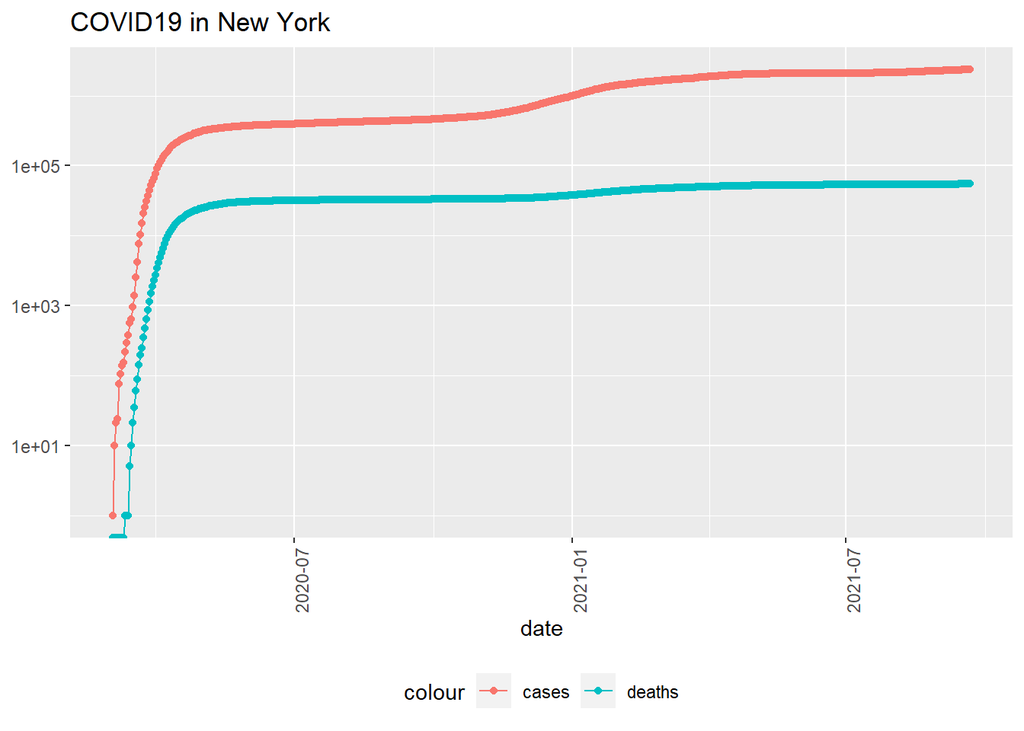

```r
state <- "New York"
US_by_state %>%
  filter(Province_State == state) %>%
  filter(cases > 0) %>%
  ggplot(aes(x = date, y = cases)) +
  geom_line(aes(color = "cases")) +
  geom_point(aes(color = "cases")) +
  geom_line(aes(y = deaths, color = "deaths")) +
  geom_point(aes(y = deaths, color = "deaths")) +
  scale_y_log10() +
  theme(legend.position="bottom",
        axis.text.x = element_text(angle = 90)) +
  labs(title = str_c("COVID19 in ", state), y= NULL)
```

#### Analyze the data

Calculating the new cases and deaths being added daily for the entire country as well as for each state. Using the *lag function* to do the same.

```r
US_by_state <- US_by_state %>%
  mutate(new_cases = cases - lag(cases),
         new_deaths = deaths - lag(deaths))
US_totals <- US_totals %>%
  mutate(new_cases = cases - lag(cases),
         new_deaths = deaths - lag(deaths))
```

Plotting the new cases and deaths on graph

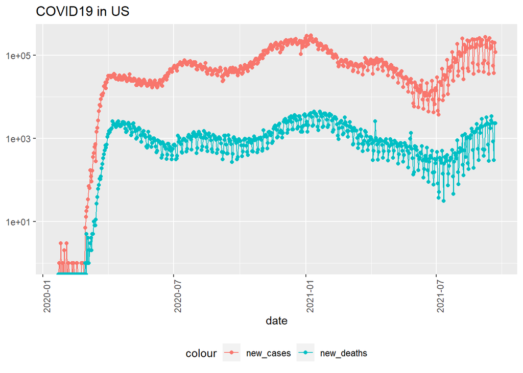

```r
US_totals %>%
  ggplot(aes(x = date, y = new_cases)) +
    geom_line(aes(color = "new_cases")) +
  geom_point(aes(color = "new_cases")) +
  geom_line(aes(y = new_deaths, color = "new_deaths")) +
  geom_point(aes(y = new_deaths, color = "new_deaths")) +
    scale_y_log10() +
    theme(legend.position="bottom",
          axis.text.x = element_text(angle = 90)) +
  labs(title = "COVID19 in US", y= NULL)
```

#### Analysis of the COVID 19 in US-new cases, new deaths curve

As can be seen from the graph, the new cases and new deaths are showing parallel curves. Also, both new cases and new deaths have a roughly *sinusoidal shape* suggesting *multiple waves* of covid-19 in the nation. The new cases keep rising till a peak and then decrease, representing the first wave of covid, followed by similar increase- peak-decrease phase of second wave. The multiple waves can be a result of new variants, carelessness of people due to pandemic fatigue etc.

#### Ploting new cases and new deaths for a particular state ( New York)

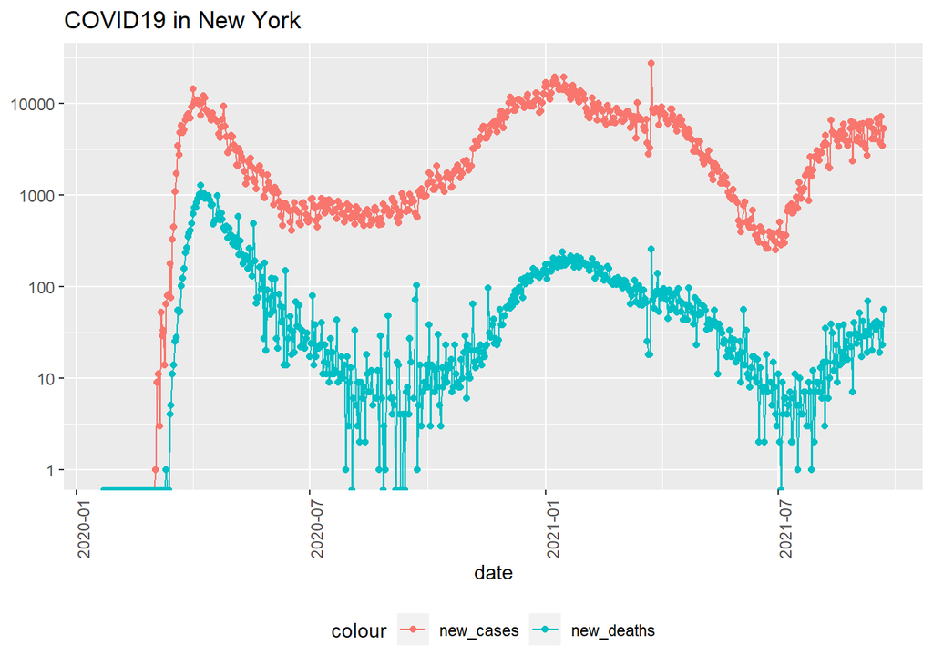

```r
state <- "New York"
US_by_state %>%
  filter(Province_State == state) %>%
  ggplot(aes(x = date, y = new_cases)) +
    geom_line(aes(color = "new_cases")) +
  geom_point(aes(color = "new_cases")) +
  geom_line(aes(y = new_deaths, color = "new_deaths")) +
  geom_point(aes(y = new_deaths, color = "new_deaths")) +
    scale_y_log10() +
    theme(legend.position="bottom",
          axis.text.x = element_text(angle = 90)) +
  labs(title = str_c("COVID19 in ", state), y= NULL)
```

#### Analysis of the COVID 19 new cases, new deaths curve of New York

The curve of New york new cases and new deaths are on expectation lines of the data for nation as a whole. But the variation in the new deaths is much more in New York. This probably can be due to some *discrepancy or bias* in the data of the new york state. Hence , the visualization suggests further investigation of this data by cross-checking it with other data-sets.

#### Best Performing States Vs Worst Performing States

we will now be comparing how different US states performed, by first calculating the cases per thousand population, deaths per thousand population and then applying the *slice_max and slice_min* functions. This will give us the best performing and worst performing states of US.

##### **Best performing 10 states**

```r
US_state_totals <- US_by_state %>%
  group_by(Province_State) %>%
  summarize(deaths = max(deaths), cases = max(cases),
            population = max(Population),
            cases_per_thou = 1000* cases / population,
            deaths_per_thou = 1000 * deaths / population) %>%
  filter(cases > 0, population > 0)
US_state_totals %>%
  slice_min(deaths_per_thou, n = 10)
```

```
## # A tibble: 10 x 6
##    Province_State           deaths  cases population cases_per_thou deaths_per_thou
##    <chr>                     <dbl>  <dbl>      <dbl>          <dbl>           <dbl>
##  1 Northern Mariana Islands      2    265      55144           4.81          0.0363
##  2 Vermont                     301  31911     623989          51.1           0.482
##  3 Hawaii                      714  76191    1415872          53.8           0.504
##  4 Virgin Islands               68   6516     107268          60.7           0.634
##  5 Alaska                      480 103327     740995         139.            0.648
##  6 Maine                      1002  84542    1344212          62.9           0.745
##  7 Puerto Rico                3092 179523    3754939          47.8           0.823
##  8 Oregon                     3624 314841    4217737          74.6           0.859
##  9 Utah                       2829 495704    3205958         155.            0.882
## 10 Washington                 7315 631023    7614893          82.9           0.961
```

##### **worst performing 10 states**

```r
US_state_totals %>%
  slice_max(deaths_per_thou, n = 10)
```

```
## # A tibble: 10 x 6
##    Province_State deaths   cases population cases_per_thou deaths_per_thou
##    <chr>           <dbl>   <dbl>      <dbl>          <dbl>           <dbl>
##  1 Mississippi      9331  477769    2976149           161.            3.14
##  2 New Jersey      27240 1137016    8882190           128.            3.07
##  3 Louisiana       13558  730099    4648794           157.            2.92
##  4 New York        54983 2382450   19453561           122.            2.83
##  5 Alabama         13460  775531    4903185           158.            2.75
##  6 Arizona         19584 1070757    7278717           147.            2.69
##  7 Massachusetts   18480  796925    6892503           116.            2.68
##  8 Rhode Island     2816  169686    1059361           160.            2.66
##  9 Arkansas         7499  486853    3017804           161.            2.48
## 10 Florida         51889 3528698   21477737           164.            2.42
```

#### Modeling the data

We will be creating a **linear model** using the **lm() function** which can predict the value of dependent variable(here deaths per thousand) for any potential value of independent variable ( here cases per thousand). Thereafter, we will plot it using ggplot.

```r
mod <- lm(deaths_per_thou ~ cases_per_thou, data = US_state_totals)
summary(mod)
```

```
##
## Call:
## lm(formula = deaths_per_thou ~ cases_per_thou, data = US_state_totals)
##
## Residuals:
##      Min       1Q   Median       3Q      Max
## -1.42361 -0.29946 -0.02553  0.27086  1.16161
##
## Coefficients:
##                Estimate Std. Error t value Pr(>|t|)
## (Intercept)    0.044428   0.243933   0.182    0.856
## cases_per_thou 0.014536   0.001927   7.543 6.04e-10 ***
## ---
## Signif. codes:  0 '***' 0.001 '**' 0.01 '*' 0.05 '.' 0.1 ' ' 1
##
## Residual standard error: 0.5097 on 53 degrees of freedom
## Multiple R-squared:  0.5177, Adjusted R-squared:  0.5086
## F-statistic:  56.9 on 1 and 53 DF,  p-value: 6.036e-10
```

```r
#best state data
US_state_totals %>% slice_min(cases_per_thou)
```

```
## # A tibble: 1 x 6
##   Province_State           deaths cases population cases_per_thou deaths_per_thou
##   <chr>                     <dbl> <dbl>      <dbl>          <dbl>           <dbl>
## 1 Northern Mariana Islands      2   265      55144           4.81          0.0363
```

```r
#worst state data
US_state_totals %>% slice_max(cases_per_thou)
```

```
## # A tibble: 1 x 6
##   Province_State deaths   cases population cases_per_thou deaths_per_thou
##   <chr>           <dbl>   <dbl>      <dbl>          <dbl>           <dbl>
## 1 Tennessee       14441 1190689    6829174           174.            2.11
```

```r
x_grid <- seq(1, 151)
new_df <- tibble(cases_per_thou = x_grid)
US_state_totals %>% mutate(pred = predict(mod))
```

```
## # A tibble: 55 x 7
##    Province_State  deaths  cases population cases_per_thou deaths_per_thou  pred
##    <chr>            <dbl>  <dbl>      <dbl>          <dbl>           <dbl> <dbl>
##  1 Alabama          13460 7.76e5    4903185          158.            2.75   2.34
##  2 Alaska             480 1.03e5     740995          139.            0.648  2.07
##  3 Arizona          19584 1.07e6    7278717          147.            2.69   2.18
##  4 Arkansas          7499 4.87e5    3017804          161.            2.48   2.39
##  5 California       68087 4.65e6   39512223          118.            1.72   1.76
##  6 Colorado          7428 6.55e5    5758736          114.            1.29   1.70
##  7 Connecticut       8477 3.86e5    3565287          108.            2.38   1.62
##  8 Delaware          1927 1.29e5     973764          132.            1.98   1.97
##  9 District of Co~   1171 5.97e4     705749           84.6           1.66   1.27
## 10 Florida          51889 3.53e6   21477737          164.            2.42   2.43
## # ... with 45 more rows
```

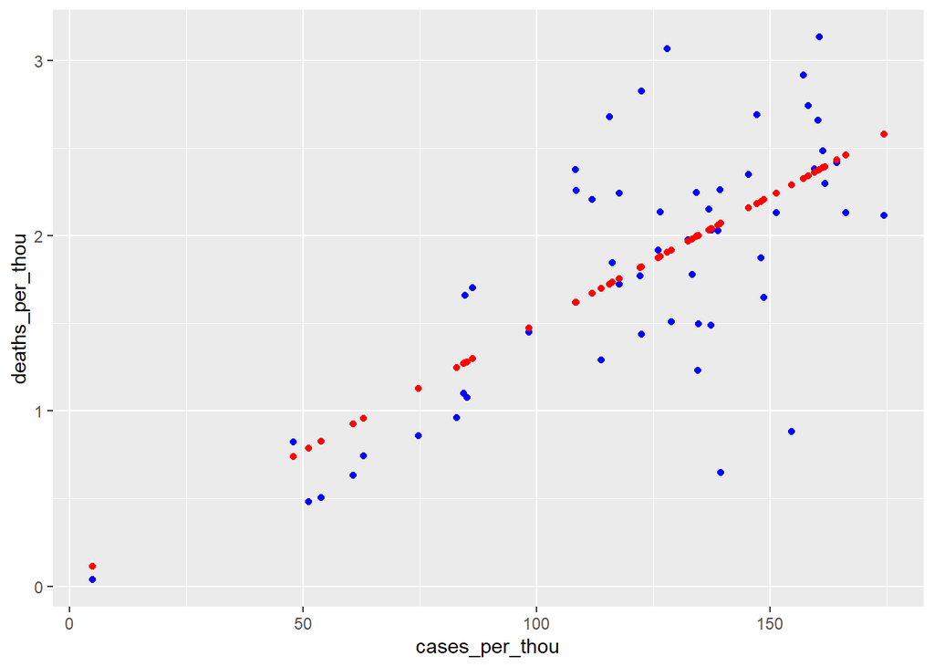

```r
US_tot_w_pred <- US_state_totals %>% mutate(pred = predict(mod))
US_tot_w_pred %>% ggplot() +
geom_point(aes(x = cases_per_thou, y = deaths_per_thou), color = "blue") +
geom_point(aes(x = cases_per_thou, y = pred), color = "red")
```

#### **Additional Self Analysis beyond what was done in class.**

**Questions of Interest** :

*To find the top 5 worst hit nations on the basis of total cases.* To find the top 5 nations with highest death rate (deaths per million population). *To Plot the covid -19 cases and deaths till date for a particular nation

##### Making a covid-19 data set of total cases and deaths till date for each country.

```r
global_by_country_total <- global %>%
  group_by(Combined_Key) %>%
  summarize(cases = sum(cases), deaths = sum(deaths),
            Population = sum(Population)) %>%
  mutate(deaths_per_mill = deaths *1000000 / Population) %>%
  select(Combined_Key,
         cases, deaths, deaths_per_mill, Population) %>%
  ungroup()
print(global_by_country_total)
```

```
## # A tibble: 279 x 5
##    Combined_Key                  cases   deaths deaths_per_mill  Population
##    <chr>                         <dbl>    <dbl>           <dbl>       <dbl>
##  1 Afghanistan                32207579  1339999         59.8    22422724416
##  2 Albania                    35659318   660570        408.      1617323600
##  3 Alberta, Canada            56586905   620087        249.      2493427490
##  4 Algeria                    46687604  1336663         53.0    25214349725
##  5 Andorra                     4043707    46832       1065.        43963785
##  6 Angola                      9655335   235023         13.0    18109313668
##  7 Anguilla, United Kingdom      24686        1          0.123      8146086
##  8 Anhui, China                 592158     3533          0.0917 38513160000
##  9 Antigua and Barbuda          313853     9069        166.        54643824
## 10 Argentina                1050978296 23753939        925.     25671201336
## # ... with 269 more rows
```

##### worst five hit nations in terms of total cases ?

```r
worst_five <- global_by_country_total %>%
  slice_max(cases, n = 5)
print(worst_five)
```

```
## # A tibble: 5 x 5
##   Combined_Key       cases    deaths deaths_per_mill   Population
##   <chr>              <dbl>     <dbl>           <dbl>        <dbl>
## 1 US           10200035090 194835033            971. 200644966347
## 2 India         6830338887  91802909            111. 829382635385
## 3 Brazil        4886025576 135006706           1107. 122009100766
## 4 Russia        1627167413  36030840            411.  87560676000
## 5 France        1536073778  35347192            892.  39621021784
```

##### Plotting a bar graph to represent the worst 5 hit countries

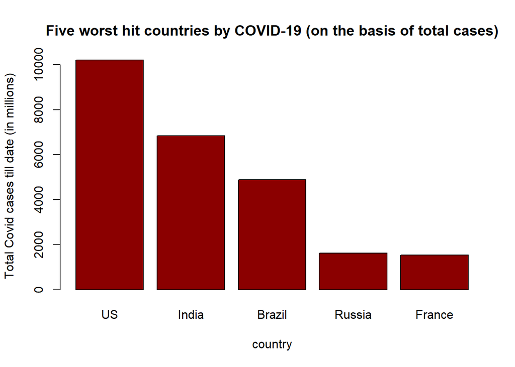

```r
barplot(worst_five$cases/1000000,
main = "Five worst hit countries by COVID-19 (on the basis of total cases)",
xlab = "country",
ylab = "Total Covid cases till date (in millions)",
names.arg = c("US","India","Brazil","Russia","France"),
col = "darkred",
horiz = FALSE)
```

##### Top 5 countries with highest casualities.

```r
worst_five_bydeath <- global_by_country_total %>%
  slice_max(deaths, n = 5)
print(worst_five_bydeath)
```

```
## # A tibble: 5 x 5
##   Combined_Key       cases    deaths deaths_per_mill   Population
##   <chr>              <dbl>     <dbl>           <dbl>        <dbl>
## 1 US           10200035090 194835033            971. 200644966347
## 2 Brazil        4886025576 135006706           1107. 122009100766
## 3 India         6830338887  91802909            111. 829382635385
## 4 Mexico         791302523  71037444            972.  73097187592
## 5 Peru           601580961  57720203           3098.  18629092990
```

##### Top 5 nations with highest death rate (deaths per million population) ?

```r
highest_death_rate <- global_by_country_total %>%
  slice_max(deaths_per_mill, n = 5)
print(highest_death_rate)
```

```
## # A tibble: 5 x 5
##   Combined_Key               cases   deaths deaths_per_mill  Population
##   <chr>                      <dbl>    <dbl>           <dbl>       <dbl>
## 1 Peru                   601580961 57720203           3098. 18629092990
## 2 San Marino               1448109    33977           1753.    19378598
## 3 Belgium                308765505  9195722           1331.  6907411136
## 4 Bosnia and Herzegovina  55272059  2307423           1243.  1856941290
## 5 Hungary                192037493  6750754           1232.  5477418450
```

##### Plot of top 5 countries with highest death rate.

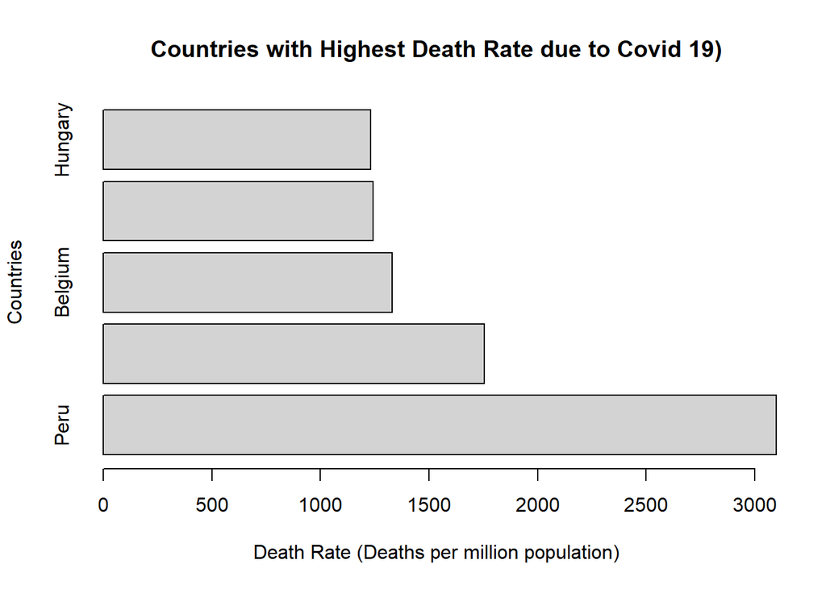

```r
barplot(highest_death_rate$deaths_per_mill,
main = "Countries with Highest Death Rate due to Covid 19)",
xlab = "Death Rate (Deaths per million population)",
ylab = "Countries",
names.arg = c("Peru","San Marino","Belgium","Bosnia & Herzegoniva","Hungary"),
col = "Light grey",
horiz = T )
```

##### Plotting the covid-19 cases and deaths for the 2nd worst hit nation in the world that is **“India”**.

*We have already plotted this curve for worst hit nation which is United States.*

```r
global_by_country <- global %>%
  group_by(Combined_Key, date) %>%
  summarize(cases = sum(cases), deaths = sum(deaths),
            Population = sum(Population)) %>%
  mutate(deaths_per_mill = deaths *1000000 / Population) %>%
  select(Combined_Key, date,
         cases, deaths, deaths_per_mill, Population) %>%
  ungroup()
print(global_by_country)
```

```
## # A tibble: 153,895 x 6
##    Combined_Key date       cases deaths deaths_per_mill Population
##    <chr>        <date>     <dbl>  <dbl>           <dbl>      <dbl>
##  1 Afghanistan  2020-02-24     5      0               0   38928341
##  2 Afghanistan  2020-02-25     5      0               0   38928341
##  3 Afghanistan  2020-02-26     5      0               0   38928341
##  4 Afghanistan  2020-02-27     5      0               0   38928341
##  5 Afghanistan  2020-02-28     5      0               0   38928341
##  6 Afghanistan  2020-02-29     5      0               0   38928341
##  7 Afghanistan  2020-03-01     5      0               0   38928341
##  8 Afghanistan  2020-03-02     5      0               0   38928341
##  9 Afghanistan  2020-03-03     5      0               0   38928341
## 10 Afghanistan  2020-03-04     5      0               0   38928341
## # ... with 153,885 more rows
```

#### Plotting the trend of cases and deaths for India till date.

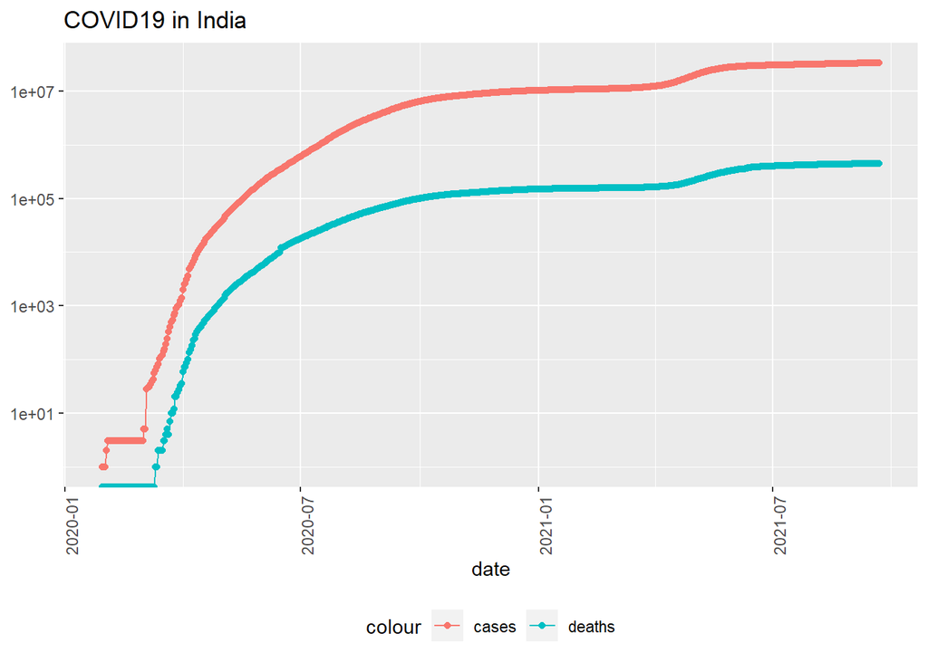

```r
nation <-"India"
global_by_country %>%
  filter(cases > 0) %>% filter(Combined_Key == nation) %>%
  ggplot(aes(x = date, y = cases)) +
  geom_line(aes(color = "cases")) +
  geom_point(aes(color = "cases")) +
  geom_line(aes(y = deaths, color = "deaths")) +
  geom_point(aes(y = deaths, color = "deaths")) +
  scale_y_log10() +
  theme(legend.position="bottom",
        axis.text.x = element_text(angle = 90)) +
  labs(title =  str_c("COVID19 in ", nation ), y= NULL)
```

#### Conclusion

The Covid-19 analysis leads us to the conclusion that the pandemic started in USA with a very high rate initially, but then slowly decreased in rate. This may be due to localised herd immunity and better administrative response to deal with the pandemic.These findings have been inferred by plotting the total cases and deaths for the nation. Similar plot drawn for the state of New York supports these findings. Also the curves of new daily cases and deaths being added also suppliment the same findings as true.

Also, the analysis of the global Covid data leads us to the conclusion that countries with higher population, elder demography, and inadequate health infrastructure are at the top of chart in terms of cases and casualities by covid. For Ex. Brazil and India are both very populous nation with a very weak health system and both occupy top 3 positions in terms of covid cases and casuality.

Also, It is a little surprising that how a developed nation like US, with one of the finest health systems, has the highest number of cases and casuality due to covid till date. One possible explanation for this can be due to more accurate reporting system adopted by US as compared to other nations.

#### Possible Sources of Bias

The possible sources of bias can be at various levels:

Collection of data level : * due to inadequate/non-representative sample being surveyed. * due to false positive/negative covid- 19 test reports * due to different reporting systems adopted by different states. For ex. some states may be disregarding deaths due to heart-attack post covid recovery as covid deaths * due to human error in reporting the responses of survey

Analysis of Data level : * Analysis after data visualization can bring in personal bias in some form. * Any bias in the data can be propogated to become bigger through the modeling.